# Mini-curso Noções básicas do R

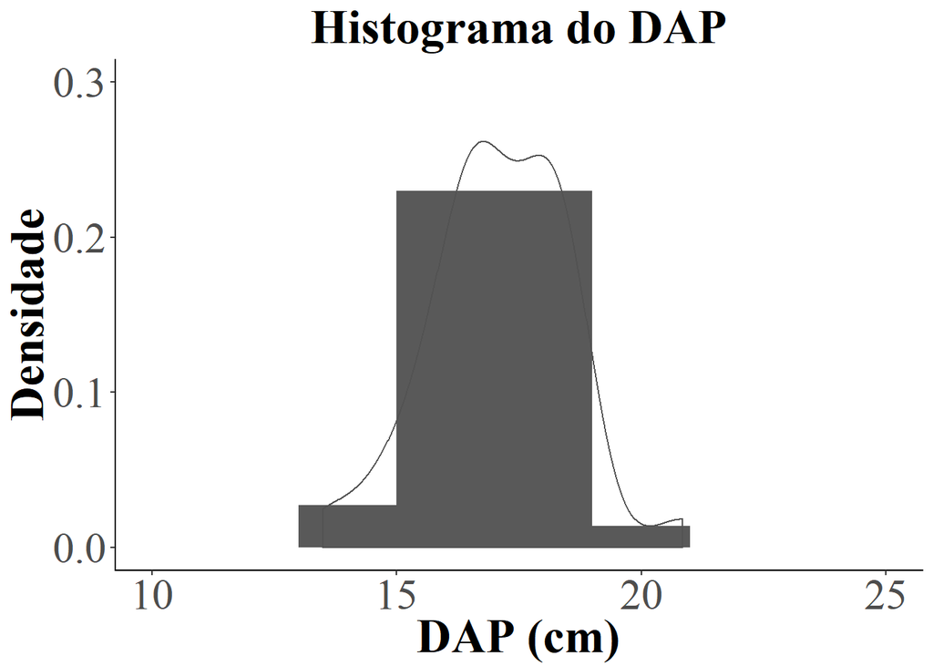

```r
b + geom_histogram(binwidth = 2) +
  labs(x = "DAP (cm)", y = "Densidade", title = "Histograma do DAP") +
  coord_cartesian(xlim = c(10,25), ylim = c(0, .3)) +
  geom_density(color = "grey32")
```

Podemos utilizar subsetting com uma variavel categorica

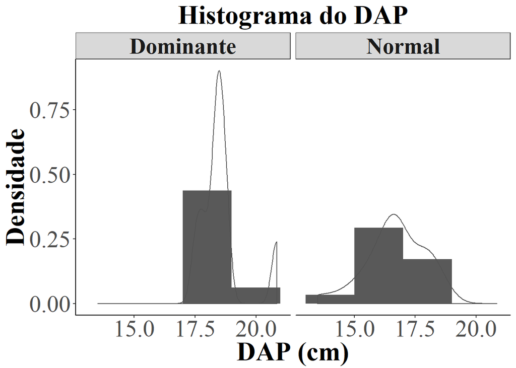

```r
b + geom_histogram(binwidth = 2) +
  labs(x = "DAP (cm)", y = "Densidade", title = "Histograma do DAP") +
  geom_density(color = "grey32") +
  facet_grid(.~DESCCATEGORIA)
```

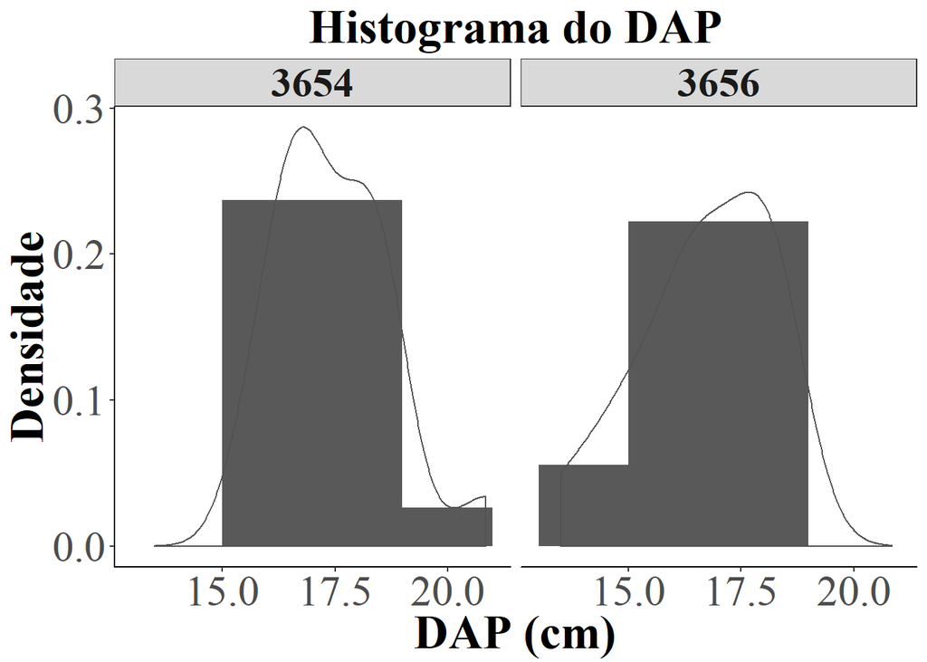

```r
b + geom_histogram(binwidth = 2) +
  labs(x = "DAP (cm)", y = "Densidade", title = "Histograma do DAP") +
  geom_density(color = "grey32") +
  facet_grid(.~CODTALHAO)
```

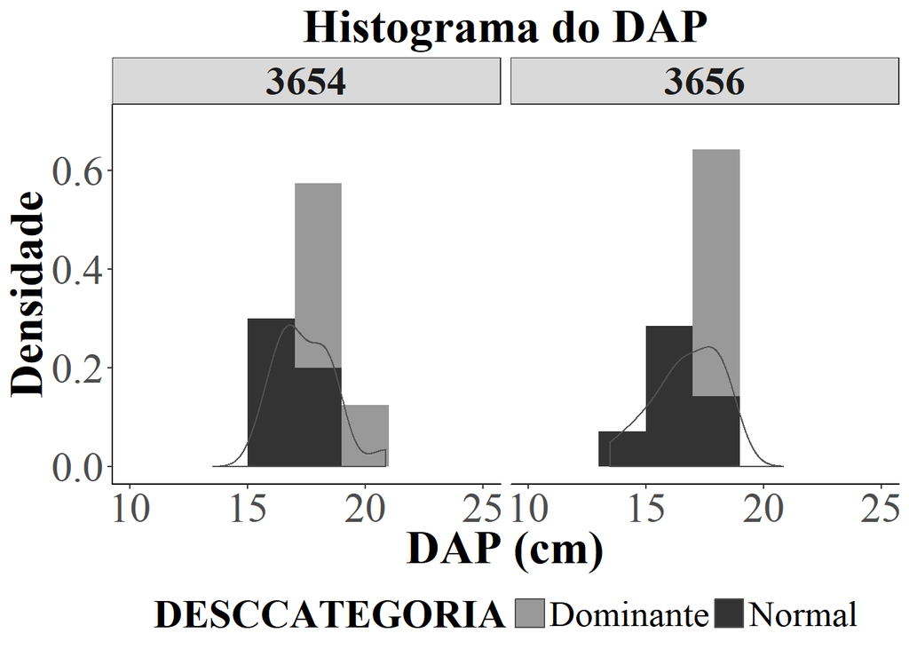

```r
b + geom_histogram(binwidth = 2, aes(fill = DESCCATEGORIA)) +
  labs(x = "DAP (cm)", y = "Densidade", title = "Histograma do DAP") +
  coord_cartesian(xlim = c(10,25), ylim = c(0, .7)) +
  geom_density(color = "grey32") +
  facet_grid(.~CODTALHAO)
```

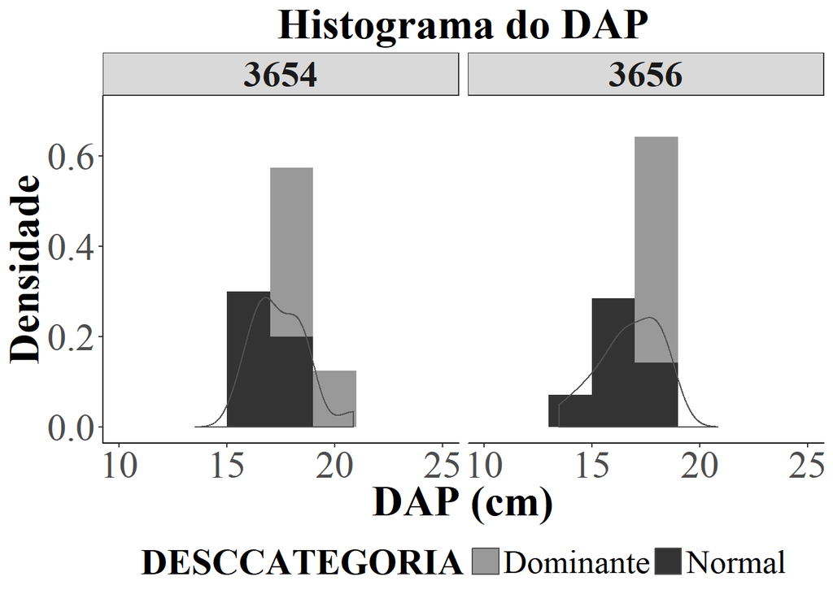

```r
b + geom_histogram(binwidth = 2, aes(fill = DESCCATEGORIA)) +
  labs(x = "DAP (cm)", y = "Densidade", title = "Histograma do DAP") +
  coord_cartesian(xlim = c(10,25), ylim = c(0, .7)) +
  geom_density(color = "grey32") +
  facet_grid(.~CODTALHAO)
```

## 10.3) Boxplot

Boxplot da altura em função da qualidade da árvore

```r
c <- ggplot(dados_g, aes(x = DESCCATEGORIA, y = ALT1)) +
  theme_bw(base_family = "serif") +
  theme(
    legend.position = "bottom",
    panel.grid.major = element_blank(),
    panel.grid.minor = element_blank(),
    panel.border = element_blank(),
    plot.title = element_text(size = 26, face = "bold", hjust = 0.5),
    axis.title = element_text(size = 26, face = "bold"),
    axis.text = element_text(size = 23),
    axis.line.x = element_line(color = "black"),
    axis.line.y = element_line(color = "black"),
    strip.text.x = element_text(size = 22,face = "bold"),
    legend.text = element_text(size = 20),
    legend.title = element_text(size = 22, face="bold") ) +
  scale_colour_grey(start = 0.6, end = 0.2) +
  scale_fill_grey(start = 0.6, end = 0.2)
```

Boxplot basico

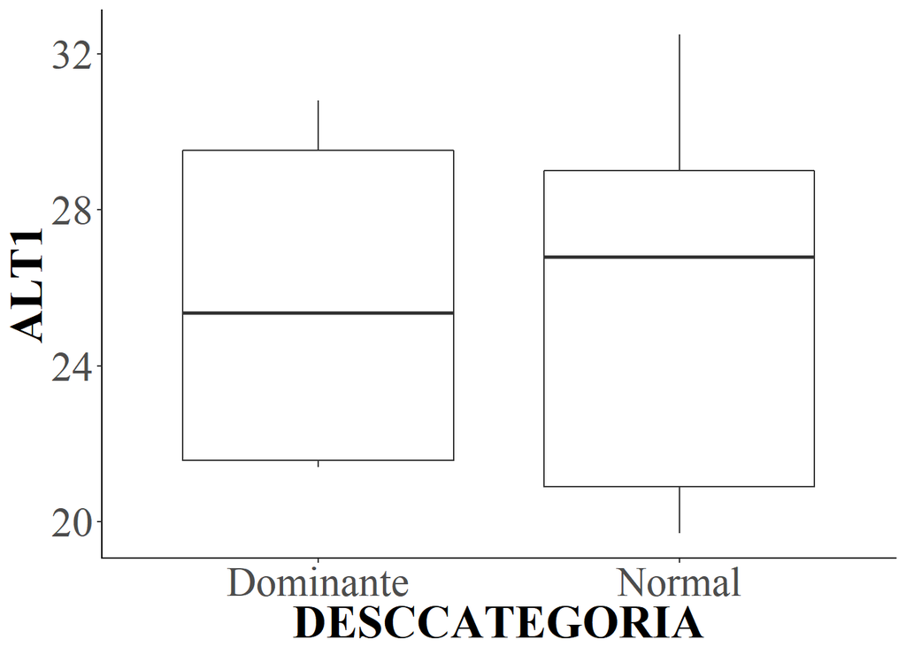

```r
c + geom_boxplot()
```

cor personalizada

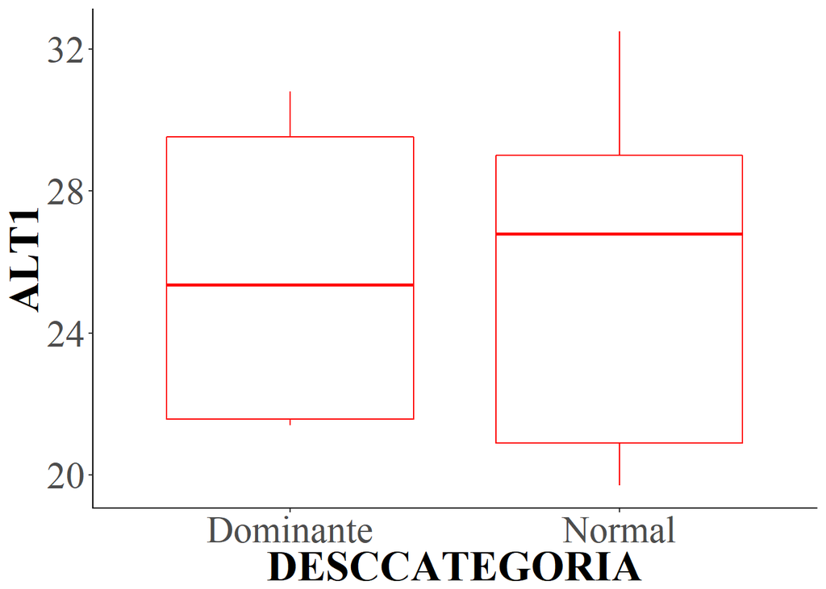

```r
c + geom_boxplot(color = "red")
```

Preenchimento personalizado

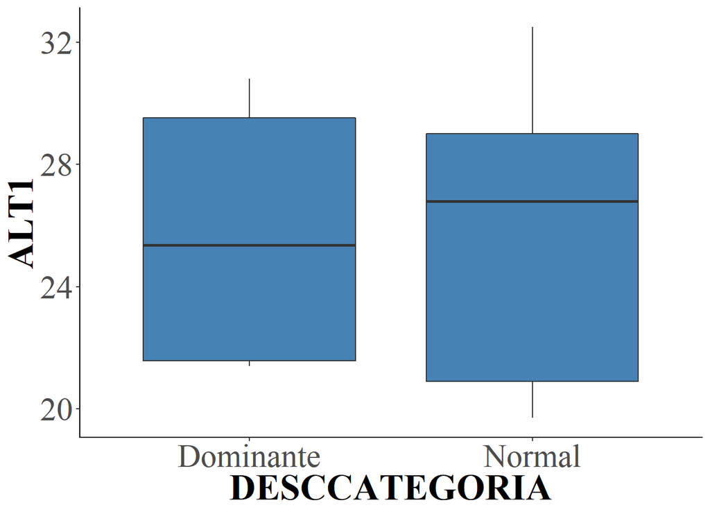

```r
c + geom_boxplot(fill = "steelblue")
```

TItulo

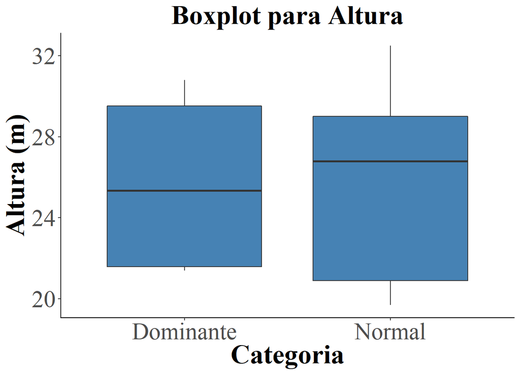

```r
c + geom_boxplot(fill = "steelblue") +
  labs(x = "Categoria", y = "Altura (m)", title = "Boxplot para Altura")
```

Adicionar ponto de media

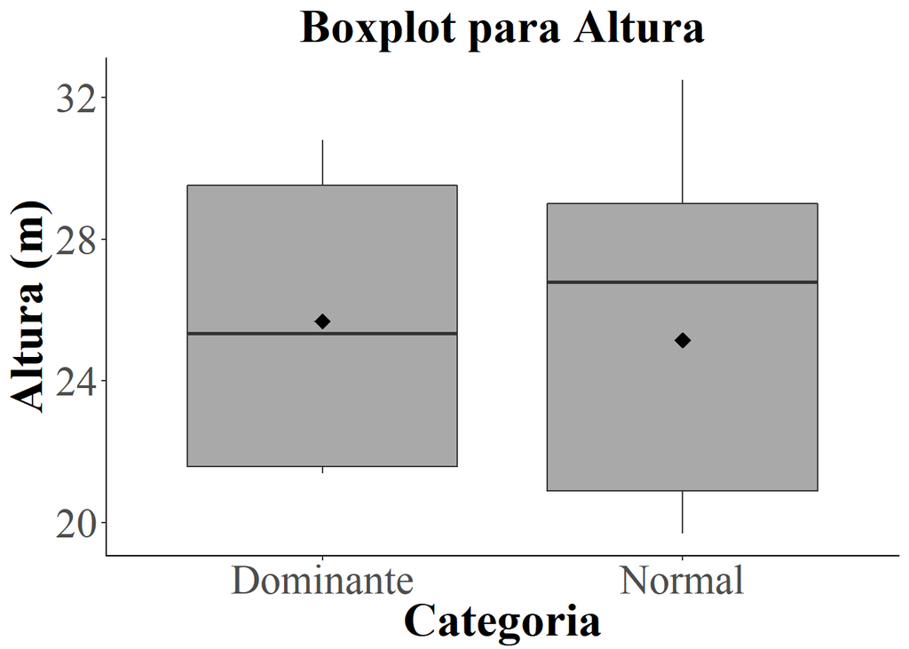

```r
c + geom_boxplot(fill = "darkgray") +
  labs(x = "Categoria", y = "Altura (m)", title = "Boxplot para Altura") +
  stat_summary(fun.y=mean, geom="point", shape=18, size = 4, show.legend=FALSE)
```

Podemos utilizar subsetting com uma variavel categorica (factor)

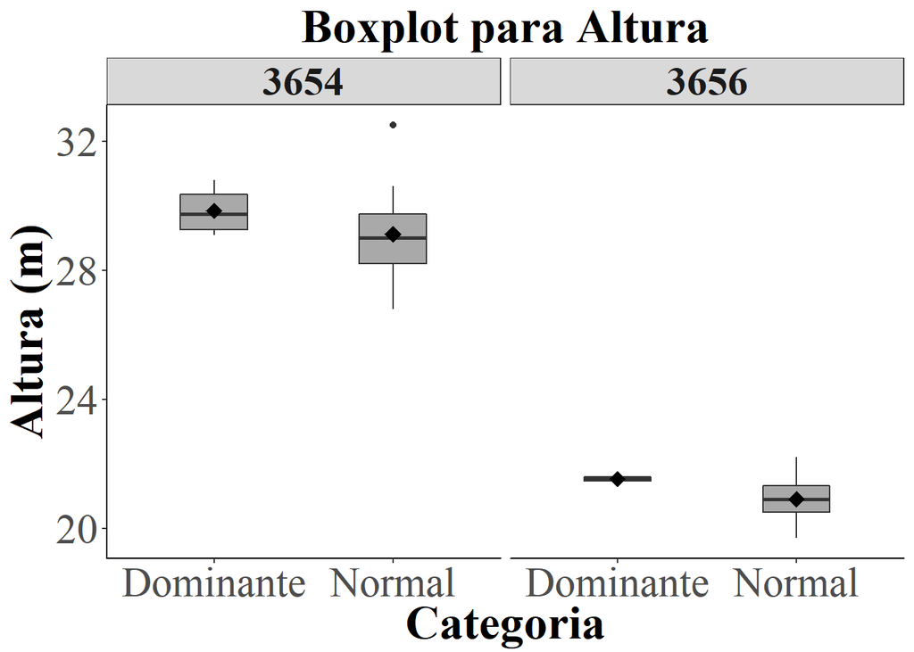

```r
c + geom_boxplot(fill = "darkgray") +
  labs(x = "Categoria", y = "Altura (m)", title = "Boxplot para Altura") +
  stat_summary(fun.y=mean, geom="point", shape=18, size = 4, show.legend=FALSE) +
  facet_grid(.~CODTALHAO)
```

Normalmente, ggplot2 nao plota boxplots sem categoria; Podemos improvisar e criar uma categoria falsa

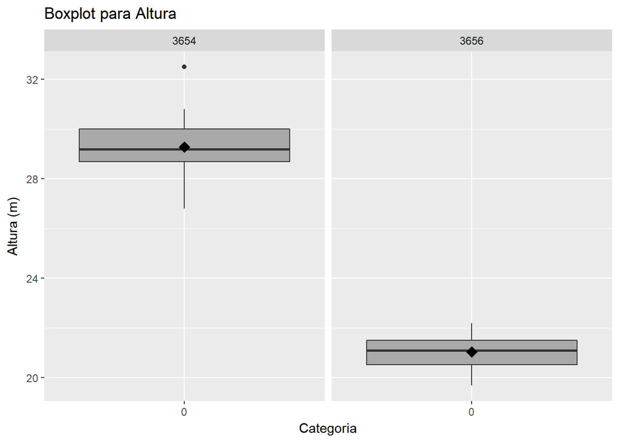

```r
ggplot(dados_g2, aes(x = factor(0), y = ALT1)) +
  geom_boxplot(fill = "darkgray") +
  labs(x = "Categoria", y = "Altura (m)", title = "Boxplot para Altura") +
  stat_summary(fun.y=mean, geom="point", shape=18, size = 4, show.legend=FALSE) +
  facet_grid(.~CODTALHAO)
```

## 10.4) Linhas

Dado utilizado: Orange: Crescimento de árvores de laranja.

```r
head(Orange,10)
```

| Tree | age | circumference |
| --- | --- | --- |
| 1 | 118 | 30 |
| 1 | 484 | 58 |
| 1 | 664 | 87 |
| 1 | 1004 | 115 |
| 1 | 1231 | 120 |
| 1 | 1372 | 142 |
| 1 | 1582 | 145 |
| 2 | 118 | 33 |
| 2 | 484 | 69 |
| 2 | 664 | 111 |

Gráfico da circunferência em função da idade.

Primeiro cira-se a base do gráfico

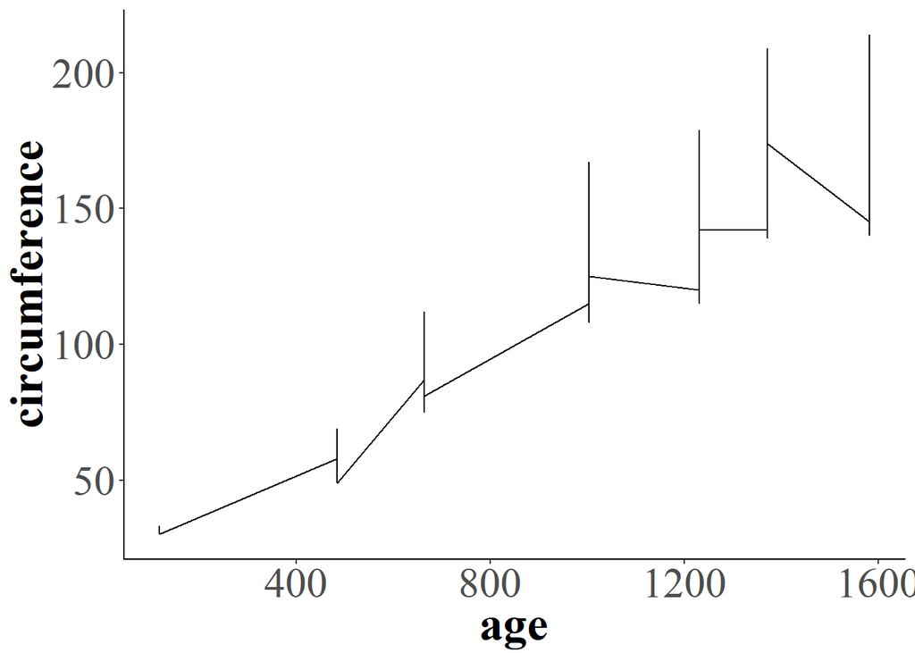

```r
d <- ggplot(Orange, aes(x = age, y = circumference)) +
  theme_bw(base_family = "serif") +
  theme(
    legend.position = "bottom",
    panel.grid.major = element_blank(),
    panel.grid.minor = element_blank(),
    panel.border = element_blank(),
    plot.title = element_text(size = 26, face = "bold", hjust = 0.5),
    axis.title = element_text(size = 26, face = "bold"),
    axis.text = element_text(size = 23),
    axis.line.x = element_line(color = "black"),
    axis.line.y = element_line(color = "black"),
    strip.text.x = element_text(size = 22,face = "bold"),
    legend.text = element_text(size = 20),
    legend.title = element_text(size = 22, face="bold") ) +
  scale_colour_grey(start = 0.6, end = 0.2) +
  scale_fill_grey(start = 0.6, end = 0.2)

d + geom_line()
```

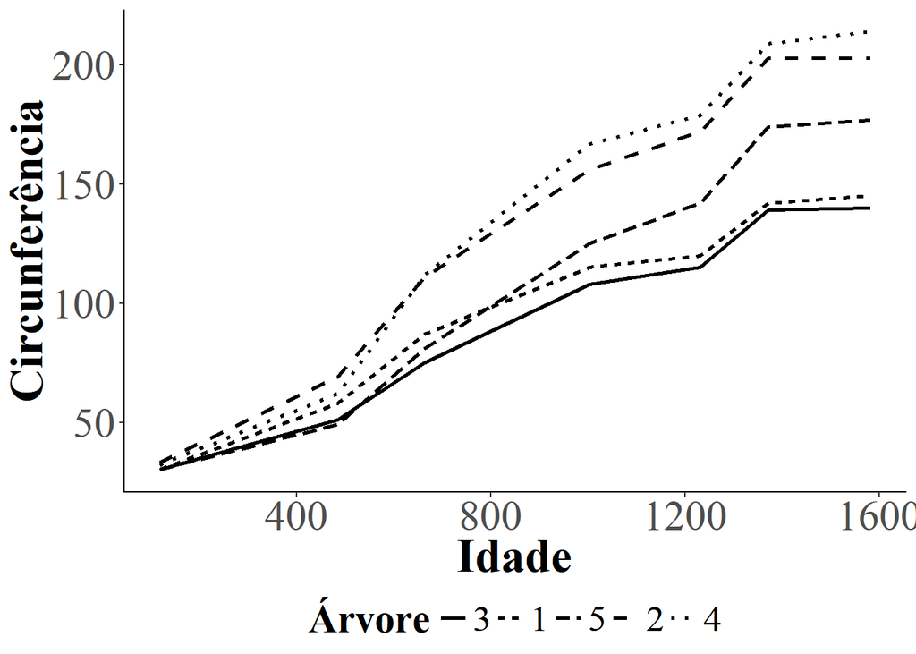

```r
# Linhas por árvore
d + geom_line(aes(linetype=Tree), size=1) +
  labs(x = "Idade", y = "Circunferência", linetype="Árvore" )
```

## 10.5) Exportar Graficos

```r
disp <- a + geom_point(size = 4, aes(color=DESCCATEGORIA)) +
  labs(x="DAP (cm)", y="Altura (m)", colour = "Categoria", title = "Grafico de Dispersao") +
  theme_bw(base_family = "serif") +
  theme(
    legend.position = "bottom",
    panel.grid.major = element_blank(),
    panel.grid.minor = element_blank(),
    panel.border = element_blank(),
    plot.title = element_text(size = 26, face = "bold", hjust = 0.5),
    axis.title = element_text(size = 26, face = "bold"),
    axis.text = element_text(size = 23),
    axis.line.x = element_line(color = "black"),
    axis.line.y = element_line(color = "black"),
    strip.text.x = element_text(size = 22,face = "bold"),
    legend.text = element_text(size = 20),
    legend.title = element_text(size = 22, face="bold") ) +
  coord_cartesian(ylim = c(15,35)) +
  geom_smooth(method = "lm", color = "red", se=FALSE) +
  facet_grid(.~CODTALHAO) +
  scale_colour_grey(start = 0.6, end = 0.2)

boxp <- c + geom_boxplot(fill = "darkgray") +
  labs(x = "Categoria", y = "Altura (m)", title = "Boxplot para Altura") +
  stat_summary(fun.y=mean, geom="point", shape=18, size = 4, show.legend=FALSE)

hist1 <- b + geom_histogram(binwidth = 2) +
  labs(x = "DAP (cm)", y = "Densidade", title = "Histograma do DAP") +
  geom_density(color = "grey32") +
  facet_grid(.~DESCCATEGORIA)

hist2 <- b + geom_histogram(binwidth = 2) +
  labs(x = "DAP (cm)", y = "Densidade", title = "Histograma do DAP") +
  coord_cartesian(xlim = c(10,25), ylim = c(0, .3)) +
  geom_density(color = "grey32")
```

Para salvarmos o grafico, basta usar o comando ggsave Por padrao este comando salva o ultimo grafico gerado para salvarmos um objeto especifico, basta indica-lo na função:

Salvar um dos graficos gerados pelo ggplot2

```r
ggsave("disp.jpeg",  disp, width = 12, height = 10)
ggsave("boxp.jpeg",  boxp, width = 12, height = 10)
ggsave("hist1.jpeg",  hist1, width = 12, height = 10)
ggsave("hist2.jpeg",  hist2, width = 12, height = 10)
```

# 11) Atividade

Base de dados utilizada:

iris: Composta por comprimento e largura de sépalas e pétalas de 3 espécies de flores.

```r
iris
```

| Sepal.Length | Sepal.Width | Petal.Length | Petal.Width | Species |
| --- | --- | --- | --- | --- |
| 5.1 | 3.5 | 1.4 | 0.2 | setosa |
| 4.9 | 3.0 | 1.4 | 0.2 | setosa |
| 4.7 | 3.2 | 1.3 | 0.2 | setosa |
| 4.6 | 3.1 | 1.5 | 0.2 | setosa |
| 5.0 | 3.6 | 1.4 | 0.2 | setosa |
| 5.4 | 3.9 | 1.7 | 0.4 | setosa |
| 4.6 | 3.4 | 1.4 | 0.3 | setosa |
| 5.0 | 3.4 | 1.5 | 0.2 | setosa |
| 4.4 | 2.9 | 1.4 | 0.2 | setosa |
| 4.9 | 3.1 | 1.5 | 0.1 | setosa |
| 5.4 | 3.7 | 1.5 | 0.2 | setosa |
| 4.8 | 3.4 | 1.6 | 0.2 | setosa |
| 4.8 | 3.0 | 1.4 | 0.1 | setosa |
| 4.3 | 3.0 | 1.1 | 0.1 | setosa |
| 5.8 | 4.0 | 1.2 | 0.2 | setosa |
| 5.7 | 4.4 | 1.5 | 0.4 | setosa |
| 5.4 | 3.9 | 1.3 | 0.4 | setosa |
| 5.1 | 3.5 | 1.4 | 0.3 | setosa |
| 5.7 | 3.8 | 1.7 | 0.3 | setosa |
| 5.1 | 3.8 | 1.5 | 0.3 | setosa |
| 5.4 | 3.4 | 1.7 | 0.2 | setosa |
| 5.1 | 3.7 | 1.5 | 0.4 | setosa |
| 4.6 | 3.6 | 1.0 | 0.2 | setosa |
| 5.1 | 3.3 | 1.7 | 0.5 | setosa |
| 4.8 | 3.4 | 1.9 | 0.2 | setosa |
| 5.0 | 3.0 | 1.6 | 0.2 | setosa |
| 5.0 | 3.4 | 1.6 | 0.4 | setosa |
| 5.2 | 3.5 | 1.5 | 0.2 | setosa |
| 5.2 | 3.4 | 1.4 | 0.2 | setosa |
| 4.7 | 3.2 | 1.6 | 0.2 | setosa |

[output cut: 120 more lines]

Calcular o comprimento médio das pétalas da espécie virginica

```r
mean(iris[iris$Species=="virginica", "Petal.Length"], na.rm=T)
```

```
## [1] 5.552
```

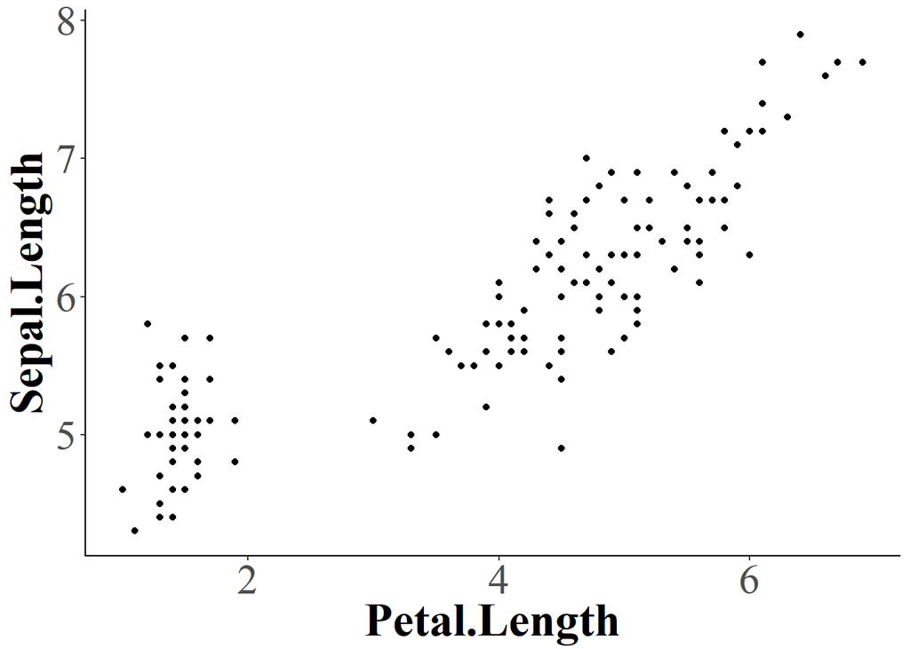

```r
base_grafico <- ggplot(iris, aes(x=Petal.Length, y = Sepal.Length)) +
  theme_bw(base_family = "serif") +
  theme(
    legend.position = "bottom",
    panel.grid.major = element_blank(),
    panel.grid.minor = element_blank(),
    panel.border = element_blank(),
    plot.title = element_text(size = 26, face = "bold", hjust = 0.5),
    axis.title = element_text(size = 26, face = "bold"),
    axis.text = element_text(size = 23),
    axis.line.x = element_line(color = "black"),
    axis.line.y = element_line(color = "black"),
    strip.text.x = element_text(size = 22,face = "bold"),
    legend.text = element_text(size = 20),
    legend.title = element_text(size = 22, face="bold") )

base_grafico + geom_point()
```

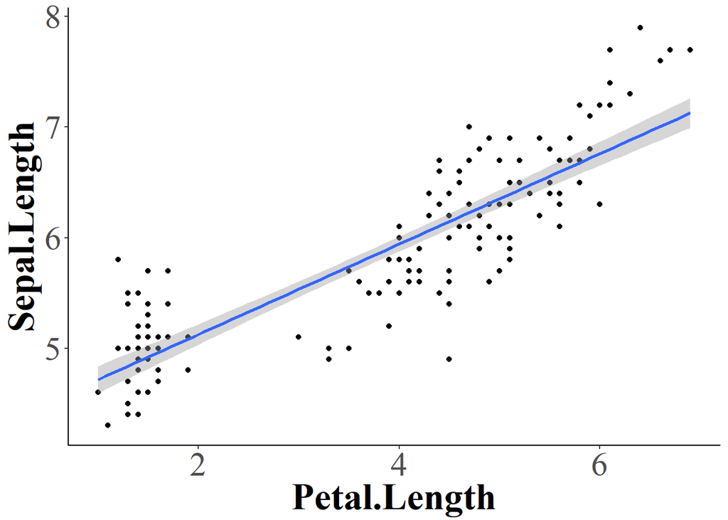

```r
base_grafico + geom_point() + geom_smooth(method = "lm")
```

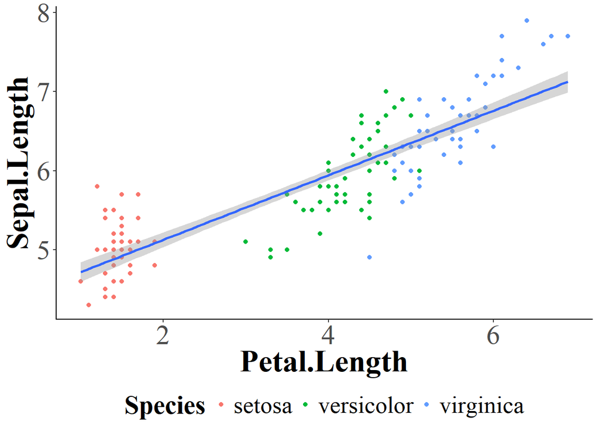

```r
base_grafico + geom_point(aes(color=Species)) + geom_smooth(method = "lm")
```

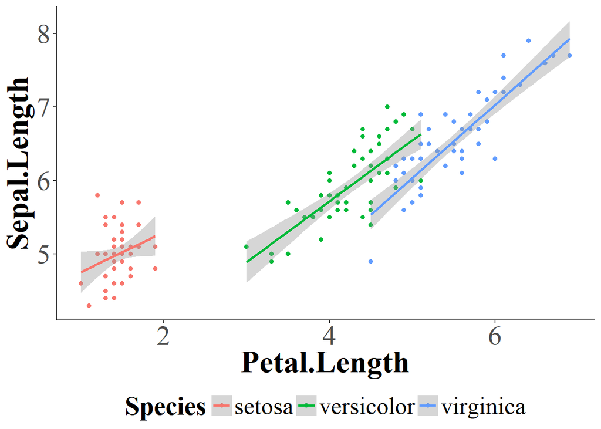

```r
base_grafico + geom_point(aes(color=Species)) + geom_smooth(aes(color=Species),method = "lm")
```

```r
iris
```

| Sepal.Length | Sepal.Width | Petal.Length | Petal.Width | Species |
| --- | --- | --- | --- | --- |
| 5.1 | 3.5 | 1.4 | 0.2 | setosa |
| 4.9 | 3.0 | 1.4 | 0.2 | setosa |
| 4.7 | 3.2 | 1.3 | 0.2 | setosa |
| 4.6 | 3.1 | 1.5 | 0.2 | setosa |
| 5.0 | 3.6 | 1.4 | 0.2 | setosa |
| 5.4 | 3.9 | 1.7 | 0.4 | setosa |
| 4.6 | 3.4 | 1.4 | 0.3 | setosa |
| 5.0 | 3.4 | 1.5 | 0.2 | setosa |
| 4.4 | 2.9 | 1.4 | 0.2 | setosa |
| 4.9 | 3.1 | 1.5 | 0.1 | setosa |
| 5.4 | 3.7 | 1.5 | 0.2 | setosa |
| 4.8 | 3.4 | 1.6 | 0.2 | setosa |
| 4.8 | 3.0 | 1.4 | 0.1 | setosa |
| 4.3 | 3.0 | 1.1 | 0.1 | setosa |
| 5.8 | 4.0 | 1.2 | 0.2 | setosa |
| 5.7 | 4.4 | 1.5 | 0.4 | setosa |
| 5.4 | 3.9 | 1.3 | 0.4 | setosa |
| 5.1 | 3.5 | 1.4 | 0.3 | setosa |
| 5.7 | 3.8 | 1.7 | 0.3 | setosa |
| 5.1 | 3.8 | 1.5 | 0.3 | setosa |
| 5.4 | 3.4 | 1.7 | 0.2 | setosa |
| 5.1 | 3.7 | 1.5 | 0.4 | setosa |
| 4.6 | 3.6 | 1.0 | 0.2 | setosa |
| 5.1 | 3.3 | 1.7 | 0.5 | setosa |
| 4.8 | 3.4 | 1.9 | 0.2 | setosa |
| 5.0 | 3.0 | 1.6 | 0.2 | setosa |
| 5.0 | 3.4 | 1.6 | 0.4 | setosa |
| 5.2 | 3.5 | 1.5 | 0.2 | setosa |
| 5.2 | 3.4 | 1.4 | 0.2 | setosa |
| 4.7 | 3.2 | 1.6 | 0.2 | setosa |

[output cut: 120 more lines]

# 12) Exportar dados

Para se exportar dados no R, utiliza-se a família de funções write, como write.table, para o formato .txt e write.csv para o formato .csv;

O modelo utilizado e: write.csv2(nome do objeto a exportar, “nome do arquivo.csv”).

Semelhante a família das funções read, utiliza-se write.csv2 para arquivos com separador “;” e dec “,” (padrão nacional/europeu); e write.csv para arquivos com separador “,” e dec “.” (padrão americano).

Deve-se atentar a extensão do arquivo no nome:

```r
write.csv2(iris, "iris.csv")
```

Por padrão os nomes das linhas são inseridas no arquivo. Para que isto não aconteça, utiliza-se row.names = FALSE:

```r
write.csv2(dados, "iris.csv", row.names = FALSE)
```